# 第一讲 `SAS` 入门

王宁宁

## 1、课程介绍

### `SAS` 简介

#### `SAS` 公司

- `SAS`主页 [这里](https://www.sas.com/zh_cn/home.html)
- `SAS`认证 [这里](https://www.sas.com/zh_cn/certification.html)

### 课程目标

- 了解 `SAS`并掌握`SAS` 基本使用
- `SAS`认证
- 常用统计程序的`SAS`代码

### 参考教材

- The Little SAS Book (4th edition) 中文版 [代码以及数据文件](http://support.sas.com/publishing/bbu/61860/index.html)
- Common Statistical Methods for Clinical Research with SAS Examples, Second Edition

### 考核方式

- 考勤 20%
- 课堂作业 20%
- 课程论文 60%

## 2、 `SAS`软件入门

### 启动

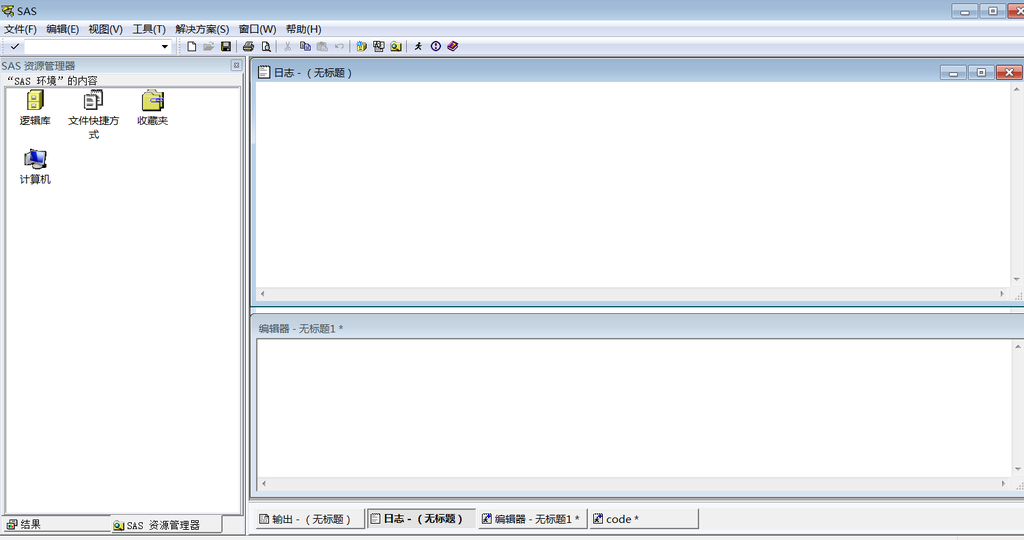

### 软件简介

### SAS语句

- SAS语句不区分大小写
- 一条语句可以持续到第二行（只要不把一个单词分开）。
- 几条语句可以用一行。
- 可以在任何一列中开始一条语句

```sas
DATA uspresidents;
INPUT President $ Party $ Number;
   DATALINES;
Adams     F  2
Lincoln   R 16
Grant     R 18
Kennedy   D 35
   ;
proc print;
RUN;
```

#### 关于SAS的注释

### SAS数据集

#### 变量和观测值

#### 数据类型

- SAS中只有两种数据类型——数值型和字符型

#### 缺失值

- 数值变量的缺失值用句号（.）表示

#### SAS数据集的大小

- 在SAS 9.1之前（prior to SAS 9.1），SAS数据集可以包含32767个变量
- 从SAS 9.1开始（beginning with SAS 9.1），SAS可包含的最多变量数由电脑可用资源决定

#### SAS命名规则

- 名字的长度要小于等于32个字节。（一个字母1个字节，一个汉字2个字节）
- 以字母或下划线开头。
- 可以包含字母、数字、或者是下划线，不能是%$!*&#@。
- 可以是小写或大写字母，且不区分大小写。

### SAS程序的基本模块

- 数据歩
- 过程歩

```sas
DATA uspresidents;
INPUT President $ Party $ Number;
   DATALINES;
Adams     F  2
Lincoln   R 16
Grant     R 18
Kennedy   D 35
   ;
proc print;
RUN;
```

### 数据步的内置循环

[figure not shown]

- SAS会自动执行: 数据步按照一行一行、一个观测值一个观测值的顺序执行

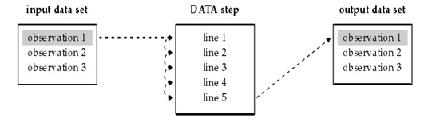

## 3、SAS数据输入

### 直接输入

### 导入向导（Import Wizard）读入xls文件

- 导入文件 `baseball.xls`下载（右键另存）

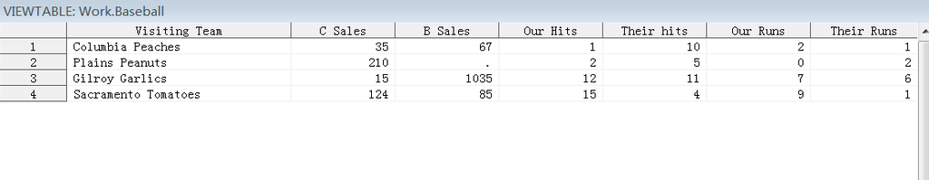

### 导入过程（IMPORT procedure）

```sas
PROC IMPORT OUT= WORK.baseball
            DATAFILE= "C:\MyRawData\Baseball.xls"
            DBMS=EXCEL REPLACE;
     RANGE="Sheet1$";
     GETNAMES=YES;
     MIXED=NO;
     SCANTEXT=YES;
     USEDATE=YES;
     SCANTIME=YES;
RUN;
```

### 读入 dat文件

- ToadJump.dat下载

```sas
DATA toads;
   INFILE 'c:\MyRawData\ToadJump.dat';
   INPUT ToadName $ Weight Jump1 Jump2 Jump3;
RUN;
* Print the data to make sure the file was read correctly;
PROC PRINT DATA = toads;
   TITLE 'SAS Data Set Toads';
RUN;
```

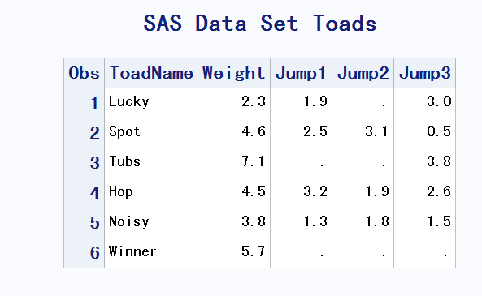

### `list input`读取空格分开的原始数据

- 青蛙跳跃比赛，记录了每只参赛青蛙的名字、体重、和三次跳跃的距离：

### `column input` 读取按固定列排列的原始数据

column input有如下优势：

- 不要求变量值之间的空格；
- 缺失值可以直接用空格代替；
- 字符串中可以包含空格；
- 可以跳过不需要的变量。

原始数据记录如下：

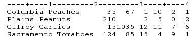

- OnionRing.dat 下载

```sas
DATA sales;
   INFILE 'c:\MyRawData\OnionRing.dat';
   INPUT VisitingTeam $ 1-20 ConcessionSales 21-24 BleacherSales 25-28
         OurHits 29-31 TheirHits 32-34 OurRuns 35-37 TheirRuns 38-40;
RUN;
* Print the data to make sure the file was read correctly;
PROC PRINT DATA = sales;
   TITLE 'SAS Data Set Sales';
RUN;
```

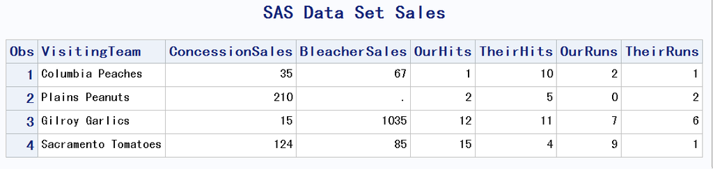

### informats读取非标准格式的原始数据

### 混合读取方式

### 临时和永久数据集

## 练习；

### 写一个数据歩的SAS程序，输入下列数据集

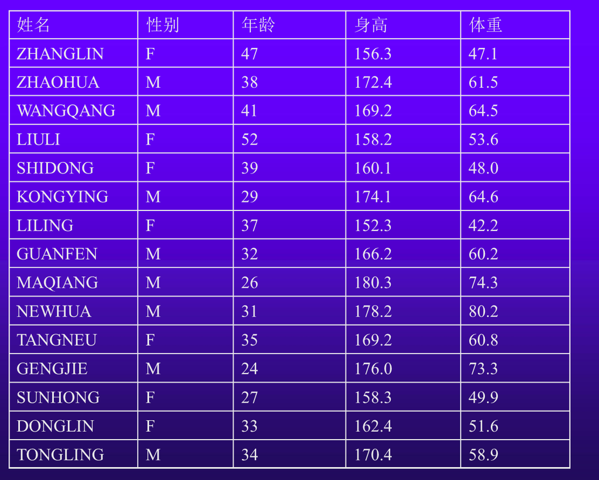

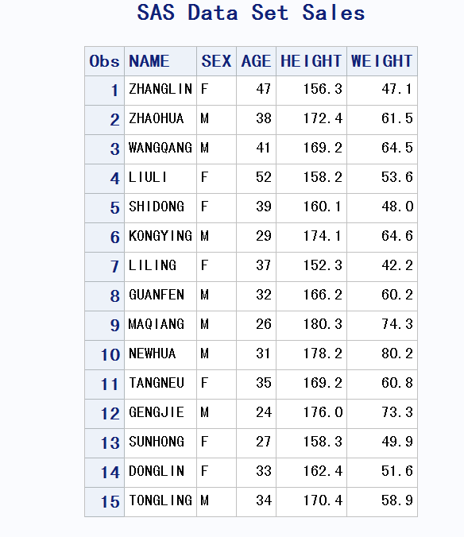